# Q3

```r
setwd("~/Coursera/8-ml/quizz")
```

## 1.

For this quiz we will be using several R packages. R package versions change over time, the right answers have been checked using the following versions of the packages.

AppliedPredictiveModeling: v1.1.6 caret: v6.0.47 ElemStatLearn: v2012.04-0 pgmm: v1.1 rpart: v4.1.8

If you aren’t using these versions of the packages, your answers may not exactly match the right answer, but hopefully should be close. Load the cell segmentation data from the AppliedPredictiveModeling package using the commands:

```r
library(AppliedPredictiveModeling)
data(segmentationOriginal)
library(caret)
library(rattle)
library(rpart)
#1. Subset the data to a training set and testing set based on the Case variable in the data set.
training <- segmentationOriginal[segmentationOriginal$Case == "Train",]
testing <- segmentationOriginal[segmentationOriginal$Case == "Test",]
dim(segmentationOriginal); summary(segmentationOriginal$Case)
```

```
## [1] 2019  119
```

```
##  Test Train
##  1010  1009
```

```r
dim(training); dim(testing)
```

```
## [1] 1009  119
```

```
## [1] 1010  119
```

```r
#2. Set the seed to 125 and fit a CART model with the rpart method using all predictor variables and default caret settings.
set.seed(125)
fit <- train(Class ~ ., method ="rpart", data = training)
#3. In the final model what would be the final model prediction for cases with the following variable values:
fit$finalModel
```

```
## n= 1009
##
## node), split, n, loss, yval, (yprob)
##       * denotes terminal node
##
## 1) root 1009 373 PS (0.63032706 0.36967294)
##   2) TotalIntenCh2< 45323.5 454  34 PS (0.92511013 0.07488987) *
##   3) TotalIntenCh2>=45323.5 555 216 WS (0.38918919 0.61081081)
##     6) FiberWidthCh1< 9.673245 154  47 PS (0.69480519 0.30519481) *
##     7) FiberWidthCh1>=9.673245 401 109 WS (0.27182045 0.72817955) *
```

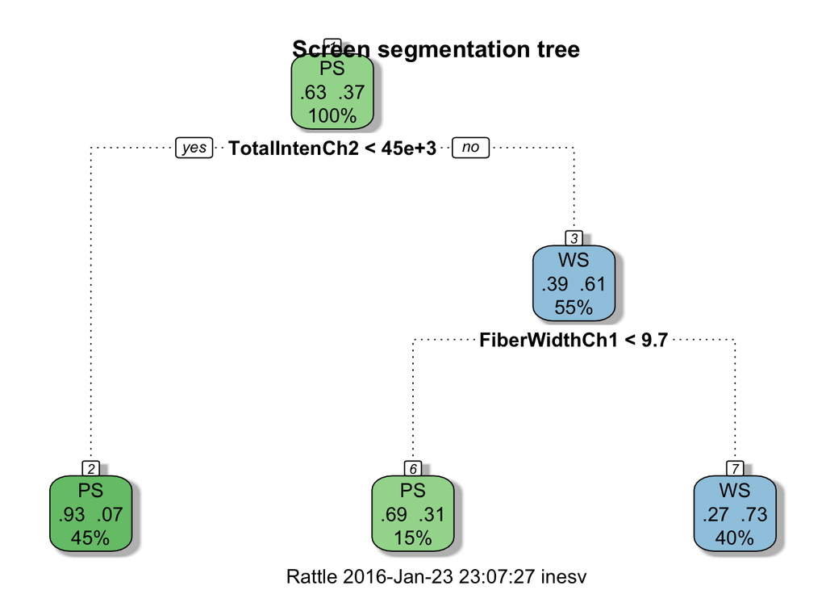

```r
fancyRpartPlot(fit$finalModel, main="Screen segmentation tree")
```

```r
#a. TotalIntench2 = 23,000; FiberWidthCh1 = 10; PerimStatusCh1=2
#b. TotalIntench2 = 50,000; FiberWidthCh1 = 10;VarIntenCh4 = 100
#c. TotalIntench2 = 57,000; FiberWidthCh1 = 8;VarIntenCh4 = 100
#d. FiberWidthCh1 = 8;VarIntenCh4 = 100; PerimStatusCh1=2
```

1. PS
2. WS
3. PS
4. WS
5. PS
6. PS
7. PS
8. Not possible to predict

—–> a. PS b. WS c. PS d. Not possible to predict

## 2.

If K is small in a K-fold cross validation is the bias in the estimate of out-of-sample (test set) accuracy smaller or bigger? If K is small is the variance in the estimate of out-of-sample (test set) accuracy smaller or bigger. Is K large or small in leave one out cross validation?

–>The bias is larger and the variance is smaller. Under leave one out cross validation K is equal to the sample size. The bias is smaller and the variance is smaller. Under leave one out cross validation K is equal to the sample size. The bias is smaller and the variance is bigger. Under leave one out cross validation K is equal to one. The bias is smaller and the variance is smaller. Under leave one out cross validation K is equal to one.

## 3.

Load the olive oil data using the commands:

```r
library(pgmm)
data(olive)
olive = olive[,-1]
summary(olive)
```

```
##       Area        Palmitic     Palmitoleic        Stearic
##  Min.   :1.0   Min.   : 610   Min.   : 15.00   Min.   :152.0
##  1st Qu.:3.0   1st Qu.:1095   1st Qu.: 87.75   1st Qu.:205.0
##  Median :3.0   Median :1201   Median :110.00   Median :223.0
##  Mean   :4.6   Mean   :1232   Mean   :126.09   Mean   :228.9
##  3rd Qu.:7.0   3rd Qu.:1360   3rd Qu.:169.25   3rd Qu.:249.0
##  Max.   :9.0   Max.   :1753   Max.   :280.00   Max.   :375.0
##      Oleic         Linoleic        Linolenic       Arachidic
##  Min.   :6300   Min.   : 448.0   Min.   : 0.00   Min.   :  0.0
##  1st Qu.:7000   1st Qu.: 770.8   1st Qu.:26.00   1st Qu.: 50.0
##  Median :7302   Median :1030.0   Median :33.00   Median : 61.0
##  Mean   :7312   Mean   : 980.5   Mean   :31.89   Mean   : 58.1
##  3rd Qu.:7680   3rd Qu.:1180.8   3rd Qu.:40.25   3rd Qu.: 70.0
##  Max.   :8410   Max.   :1470.0   Max.   :74.00   Max.   :105.0
##    Eicosenoic
##  Min.   : 1.00
##  1st Qu.: 2.00
##  Median :17.00
##  Mean   :16.28
##  3rd Qu.:28.00
##  Max.   :58.00
```

```r
dim(olive)
```

```
## [1] 572   9
```

```r
#(NOTE: If you have trouble installing the pgmm package, you can download the -code-olive-/code- dataset here: olive_data.zip. After unzipping the archive, you can load the file using the -code-load()-/code- function in R.)

#These data contain information on 572 different Italian olive oils from multiple regions in Italy. Fit a classification tree where Area is the outcome variable. Then predict the value of area for the following data frame using the tree command with all defaults

set.seed(125)
fit <- train(Area ~ ., method ="rpart", data = olive)
fit$finalModel
```

```
## n= 572
##
## node), split, n, deviance, yval
##       * denotes terminal node
##
## 1) root 572 3171.32000 4.599650
##   2) Eicosenoic>=6.5 323  176.82970 2.783282 *
##   3) Eicosenoic< 6.5 249  546.51410 6.955823
##     6) Linoleic>=1053.5 98   21.88776 5.336735 *
##     7) Linoleic< 1053.5 151  100.99340 8.006623 *
```

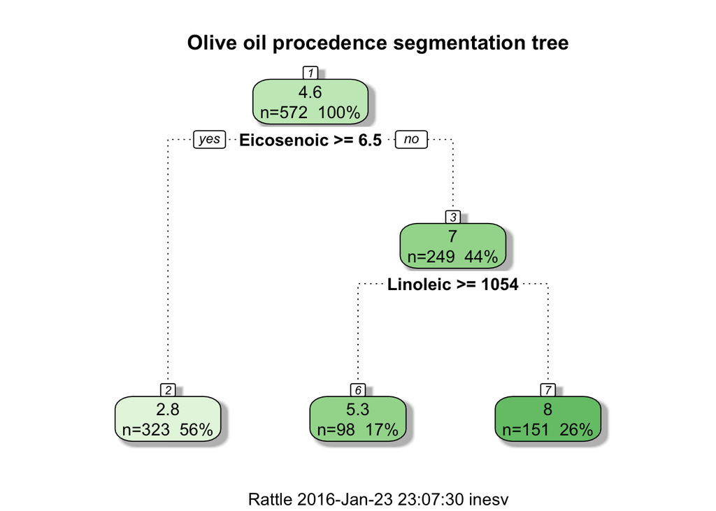

```r
fancyRpartPlot(fit$finalModel, main="Olive oil procedence segmentation tree")
```

```r
newdata = as.data.frame(t(colMeans(olive)))
predict(fit,newdata)
```

```
##        1
## 2.783282
```

```r
# What is the resulting prediction? Is the resulting prediction strange? Why or why not?
```

0.005291005 0 0.994709 0 0 0 0 0 0. The result is strange because Area is a numeric variable and we should get the average within each leaf. 4.59965. There is no reason why the result is strange. –> 2.783. It is strange because Area should be a qualitative variable - but tree is reporting the average value of Area as a numeric variable in the leaf predicted for newdata 0.005291005 0 0.994709 0 0 0 0 0 0. There is no reason why the result is strange.

# 4.

Load the South Africa Heart Disease Data and create training and test sets with the following code:

```r
library(ElemStatLearn)
data(SAheart)
set.seed(8484)
train = sample(1:dim(SAheart)[1],size=dim(SAheart)[1]/2,replace=F)
trainSA = SAheart[train,]
testSA = SAheart[-train,]

dim(SAheart)
```

```
## [1] 462  10
```

```r
summary(SAheart)
```

```
##       sbp           tobacco             ldl           adiposity
##  Min.   :101.0   Min.   : 0.0000   Min.   : 0.980   Min.   : 6.74
##  1st Qu.:124.0   1st Qu.: 0.0525   1st Qu.: 3.283   1st Qu.:19.77
##  Median :134.0   Median : 2.0000   Median : 4.340   Median :26.11
##  Mean   :138.3   Mean   : 3.6356   Mean   : 4.740   Mean   :25.41
##  3rd Qu.:148.0   3rd Qu.: 5.5000   3rd Qu.: 5.790   3rd Qu.:31.23
##  Max.   :218.0   Max.   :31.2000   Max.   :15.330   Max.   :42.49
##     famhist        typea         obesity         alcohol
##  Absent :270   Min.   :13.0   Min.   :14.70   Min.   :  0.00
##  Present:192   1st Qu.:47.0   1st Qu.:22.98   1st Qu.:  0.51
##                Median :53.0   Median :25.80   Median :  7.51
##                Mean   :53.1   Mean   :26.04   Mean   : 17.04
##                3rd Qu.:60.0   3rd Qu.:28.50   3rd Qu.: 23.89
##                Max.   :78.0   Max.   :46.58   Max.   :147.19
##       age             chd
##  Min.   :15.00   Min.   :0.0000
##  1st Qu.:31.00   1st Qu.:0.0000
##  Median :45.00   Median :0.0000
##  Mean   :42.82   Mean   :0.3463
##  3rd Qu.:55.00   3rd Qu.:1.0000
##  Max.   :64.00   Max.   :1.0000
```

```r
train <- trainSA[c("age", "alcohol", "obesity", "tobacco", "typea", "ldl", "chd")]
test <- testSA[c("age", "alcohol", "obesity", "tobacco", "typea", "ldl", "chd")]

dim(train)
```

```
## [1] 231   7
```

```r
summary(train)
```

```
##       age           alcohol          obesity         tobacco
##  Min.   :15.00   Min.   :  0.00   Min.   :14.70   Min.   : 0.000
##  1st Qu.:30.00   1st Qu.:  1.14   1st Qu.:22.64   1st Qu.: 0.000
##  Median :44.00   Median :  8.26   Median :25.91   Median : 2.000
##  Mean   :42.22   Mean   : 18.19   Mean   :25.79   Mean   : 3.646
##  3rd Qu.:55.00   3rd Qu.: 23.40   3rd Qu.:28.29   3rd Qu.: 5.275
##  Max.   :64.00   Max.   :147.19   Max.   :40.34   Max.   :27.400
##      typea            ldl              chd
##  Min.   :13.00   Min.   : 0.980   Min.   :0.0000
##  1st Qu.:46.00   1st Qu.: 3.225   1st Qu.:0.0000
##  Median :53.00   Median : 4.170   Median :0.0000
##  Mean   :52.67   Mean   : 4.577   Mean   :0.3636
##  3rd Qu.:59.00   3rd Qu.: 5.545   3rd Qu.:1.0000
##  Max.   :78.00   Max.   :15.330   Max.   :1.0000
```

```r
#Then set the seed to 13234 and fit a logistic regression model (method="glm", be sure to specify family="binomial") with Coronary Heart Disease (chd) as the outcome and age at onset, current alcohol consumption, obesity levels, cumulative tabacco, type-A behavior, and low density lipoprotein cholesterol as predictors. Calculate the misclassification rate for your model using this function and a prediction on the "response" scale:

set.seed(13234)
fit <- train(chd ~., method="glm", family="binomial", data = train)
missClass = function(values,prediction){sum(((prediction > 0.5)*1) != values)/length(values)}

missClass(train$chd, predict(fit, train))
```

```
## [1] 0.2727273
```

```r
missClass(test$chd, predict(fit, test))
```

```
## [1] 0.3116883
```

What is the misclassification rate on the training set? What is the misclassification rate on the test set?

Test Set Misclassification: 0.38 Training Set: 0.25

Test Set Misclassification: 0.32 Training Set: 0.30

Test Set Misclassification: 0.35 Training Set: 0.31

–> Test Set Misclassification: 0.31 Training Set: 0.27

# 5.

Load the vowel.train and vowel.test data sets:

```r
library(ElemStatLearn)
library(caret)
data(vowel.train)
data(vowel.test)
#Set the variable y to be a factor variable in both the training and test set. Then set the seed to 33833. Fit a random forest predictor relating the factor variable y to the remaining variables. Read about variable importance in random forests here: http://www.stat.berkeley.edu/~breiman/RandomForests/cc_home.htm#ooberr The caret package uses by default the Gini importance.

set.seed(33833)
vowel.train$y <- as.factor(vowel.train$y)
vowel.test$y <- as.factor(vowel.test$y)

tree <- train(y ~ ., method = "rf", data = vowel.train)
#Calculate the variable importance using the varImp function in the caret package. What is the order of variable importance?

importance <- varImp(tree)
?varImp
```

[output not shown]

The order of the variables is: x.10, x.7, x.5, x.6, x.8, x.4, x.9, x.3, x.1,x.2

The order of the variables is: x.2, x.1, x.5, x.6, x.8, x.4, x.9, x.3, x.7,x.10

The order of the variables is: x.1, x.2, x.3, x.8, x.6, x.4, x.5, x.9, x.7,x.10

The order of the variables is: x.10, x.7, x.9, x.5, x.8, x.4, x.6, x.3, x.1,x.2